# Lab Report — Lab 6

| **Course** | Digital Signal Processing |
| --- | --- |
| **Teacher** | prof. dr hab. Vasyl Martsenyuk, dr inż. Halyna Nahorniak |
| **Date** | 01.04.2026 |
| **Topic** | Signal Modeling – AR and MA Models |
| **Student** | Jakub Kołodziej |
| **Variant** | 11 |

## 1. Problem Statement

**Variant 11 — ARIMA Forecasting Comparison:**  
Simulate a cumulative-sum-of-white-noise signal (random walk). Fit two ARIMA models — **ARIMA(1,1,0)** and **ARIMA(1,1,1)** — to the generated signal. Analyse their forecasts, compare confidence intervals, and evaluate model quality using AIC, BIC, and residual diagnostics.

## 2. Input Data

| Parameter | Value |
| --- | --- |
| Signal type | Cumulative sum of white noise (random walk) |
| Signal length N | 200 samples |
| Driving noise distribution | N(0, 1) |
| Random seed | 42 |
| Models fitted | ARIMA(1,1,0) and ARIMA(1,1,1) |
| Differencing order d | 1 |
| Forecast horizon | 30 steps |
| Confidence interval | 95% |
| Stationarity test | Augmented Dickey-Fuller (ADF) |

## 3. Theoretical Background

### Random Walk (ARIMA(0,1,0))

A cumulative sum of white noise is equivalent to a **random walk**:

$$x[n] = x[n-1] + w[n], \quad w[n] \sim \mathcal{N}(0,\,1)$$

This process is **non-stationary** — its variance grows linearly with time. Applying first-order differencing ($d = 1$) recovers stationarity:

$$\nabla x[n] = x[n] - x[n-1] = w[n]$$

### ARIMA(p, d, q) Model

An ARIMA model applied to the $d$-th differenced series:

$$\nabla^d x[n] = -\sum_{k=1}^{p} a_k\,\nabla^d x[n-k] + \sum_{k=0}^{q} b_k\,w[n-k]$$

**ARIMA(1,1,0)** — AR(1) on first differences, no MA term:

$$\nabla x[n] = a_1\,\nabla x[n-1] + w[n]$$

**ARIMA(1,1,1)** — AR(1) and MA(1) on first differences:

$$\nabla x[n] = a_1\,\nabla x[n-1] + w[n] + b_1\,w[n-1]$$

### Model Selection Criteria

Lower AIC/BIC values indicate a better model (penalising unnecessary parameters):

$$\text{AIC} = -2\ln(\hat{L}) + 2k, \qquad \text{BIC} = -2\ln(\hat{L}) + k\ln(N)$$

where $\hat{L}$ is the maximised log-likelihood and $k$ the number of free parameters.

### Augmented Dickey-Fuller Test

- **H0**: the series has a unit root (non-stationary)
- Reject H0 if p-value <= 0.05 → series is stationary
- For a random walk p > 0.05; after differencing p <= 0.05

## 4. Implementation

### Step 1 — Libraries and Signal Generation

```
==================================================
SIGNAL STATISTICS
==================================================
  Length         : N = 200 samples
  Estimated mean : -7.9166
  Estimated var  : 16.3286
  Min / Max      : -13.527 / 4.481
==================================================
```

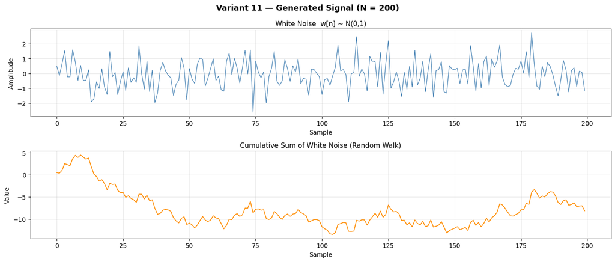

```python
import numpy as np
import matplotlib.pyplot as plt
from statsmodels.tsa.arima.model import ARIMA
from statsmodels.tsa.stattools import adfuller
from statsmodels.graphics.tsaplots import plot_acf, plot_pacf
import pandas as pd
import warnings
warnings.filterwarnings('ignore')

# Parameters
N = 200
np.random.seed(42)

# Signal generation: cumulative sum of white noise (random walk)
white_noise = np.random.normal(0, 1, N)
cumsum_signal = np.cumsum(white_noise)

print('=' * 50)
print('SIGNAL STATISTICS')
print('=' * 50)
print(f'  Length         : N = {N} samples')
print(f'  Estimated mean : {np.mean(cumsum_signal):.4f}')
print(f'  Estimated var  : {np.var(cumsum_signal):.4f}')
print(f'  Min / Max      : {cumsum_signal.min():.3f} / {cumsum_signal.max():.3f}')
print('=' * 50)

fig, axes = plt.subplots(2, 1, figsize=(14, 6))
axes[0].plot(white_noise, color='steelblue', lw=0.9)
axes[0].set_title('White Noise  w[n] ~ N(0,1)', fontsize=11)
axes[0].set_xlabel('Sample'); axes[0].set_ylabel('Amplitude'); axes[0].grid(True, alpha=0.3)

axes[1].plot(cumsum_signal, color='darkorange', lw=1.2)
axes[1].set_title('Cumulative Sum of White Noise (Random Walk)', fontsize=11)
axes[1].set_xlabel('Sample'); axes[1].set_ylabel('Value'); axes[1].grid(True, alpha=0.3)

plt.suptitle('Variant 11 — Generated Signal (N = 200)', fontsize=13, fontweight='bold')
plt.tight_layout()
plt.show()
```

### Step 2 — Stationarity Verification (ADF Test) and ACF/PACF Analysis

```
=======================================================
ADF TEST RESULTS
=======================================================
  Original signal   ADF stat: -2.3073,  p = 0.1696
  -> NON-STATIONARY (d=1 required)

  First differences ADF stat: -14.6918,  p = 0.000000
  -> STATIONARY (d=1 is sufficient)
=======================================================
```

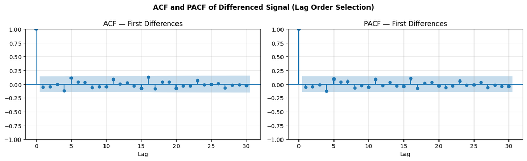

```python
# ADF test on original signal
adf_orig = adfuller(cumsum_signal)

# First differences
diff_signal = np.diff(cumsum_signal)
adf_diff = adfuller(diff_signal)

print('=' * 55)
print('ADF TEST RESULTS')
print('=' * 55)
print(f'  Original signal   ADF stat: {adf_orig[0]:.4f},  p = {adf_orig[1]:.4f}')
verdict_orig = 'NON-STATIONARY (d=1 required)' if adf_orig[1] > 0.05 else 'STATIONARY'
print(f'  -> {verdict_orig}')
print()
print(f'  First differences ADF stat: {adf_diff[0]:.4f},  p = {adf_diff[1]:.6f}')
verdict_diff = 'STATIONARY (d=1 is sufficient)' if adf_diff[1] <= 0.05 else 'NON-STATIONARY'
print(f'  -> {verdict_diff}')
print('=' * 55)

# ACF / PACF of first differences
fig, axes = plt.subplots(1, 2, figsize=(13, 4))
plot_acf(diff_signal, lags=30, ax=axes[0], title='ACF — First Differences')
axes[0].set_xlabel('Lag'); axes[0].grid(True, alpha=0.3)
plot_pacf(diff_signal, lags=30, ax=axes[1], title='PACF — First Differences')
axes[1].set_xlabel('Lag'); axes[1].grid(True, alpha=0.3)
plt.suptitle('ACF and PACF of Differenced Signal (Lag Order Selection)',
             fontsize=12, fontweight='bold')
plt.tight_layout()
plt.show()
```

### Step 3 — Model Fitting: ARIMA(1,1,0) and ARIMA(1,1,1)

```python
# Fit ARIMA(1,1,0)
model_110 = ARIMA(cumsum_signal, order=(1, 1, 0))
result_110 = model_110.fit()
print('=' * 55)
print('ARIMA(1,1,0) — ESTIMATION SUMMARY')
print('=' * 55)
print(result_110.summary())
print()

# Fit ARIMA(1,1,1)
model_111 = ARIMA(cumsum_signal, order=(1, 1, 1))
result_111 = model_111.fit()
print('=' * 55)
print('ARIMA(1,1,1) — ESTIMATION SUMMARY')
print('=' * 55)
print(result_111.summary())
```

```
=======================================================
ARIMA(1,1,0) — ESTIMATION SUMMARY
=======================================================
                               SARIMAX Results
==============================================================================
Dep. Variable:                      y   No. Observations:                  200
Model:                 ARIMA(1, 1, 0)   Log Likelihood                -267.948
Date:                Thu, 02 Apr 2026   AIC                            539.896
Time:                        11:40:06   BIC                            546.483
Sample:                             0   HQIC                           542.562
                                - 200
Covariance Type:                  opg
==============================================================================
                 coef    std err          z      P>|z|      [0.025      0.975]
------------------------------------------------------------------------------
ar.L1         -0.0495      0.080     -0.619      0.536      -0.206       0.107
sigma2         0.8651      0.088      9.859      0.000       0.693       1.037
===================================================================================
Ljung-Box (L1) (Q):                   0.00   Jarque-Bera (JB):                 0.73
Prob(Q):                              0.95   Prob(JB):                         0.69
Heteroskedasticity (H):               0.96   Skew:                             0.15
Prob(H) (two-sided):                  0.88   Kurtosis:                         2.99
===================================================================================

Warnings:
[1] Covariance matrix calculated using the outer product of gradients (complex-step).

=======================================================
ARIMA(1,1,1) — ESTIMATION SUMMARY
=======================================================
                               SARIMAX Results
==============================================================================
Dep. Variable:                      y   No. Observations:                  200
Model:                 ARIMA(1, 1, 1)   Log Likelihood                -267.731
Date:                Thu, 02 Apr 2026   AIC                            541.461
Time:                        11:40:06   BIC                            551.341
Sample:                             0   HQIC                           545.460
                                - 200
Covariance Type:                  opg
==============================================================================
                 coef    std err          z      P>|z|      [0.025      0.975]
------------------------------------------------------------------------------
ar.L1          0.4893      0.849      0.577      0.564      -1.174       2.153
ma.L1         -0.5489      0.802     -0.684      0.494      -2.121       1.023
sigma2         0.8632      0.087      9.911      0.000       0.692       1.034
===================================================================================
Ljung-Box (L1) (Q):                   0.00   Jarque-Bera (JB):                 0.83
Prob(Q):                              0.95   Prob(JB):                         0.66
Heteroskedasticity (H):               0.95   Skew:                             0.16
Prob(H) (two-sided):                  0.85   Kurtosis:                         3.01
===================================================================================

Warnings:
[1] Covariance matrix calculated using the outer product of gradients (complex-step).
```

### Step 4 — Forecast Comparison (30 Steps Ahead)

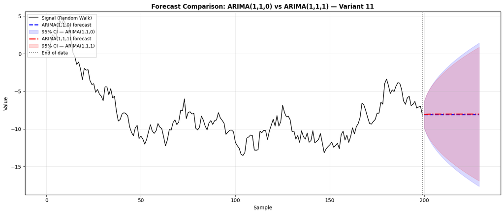

```python
n_forecast = 30
forecast_index = np.arange(N, N + n_forecast)

# ARIMA(1,1,0) forecast + 95% CI
fc_110 = result_110.get_forecast(steps=n_forecast)
mean_110 = fc_110.predicted_mean
ci_110 = pd.DataFrame(fc_110.conf_int(alpha=0.05))

# ARIMA(1,1,1) forecast + 95% CI
fc_111 = result_111.get_forecast(steps=n_forecast)
mean_111 = fc_111.predicted_mean
ci_111 = pd.DataFrame(fc_111.conf_int(alpha=0.05))

plt.figure(figsize=(14, 6))
plt.plot(np.arange(N), cumsum_signal,
         label='Signal (Random Walk)', color='black', lw=1.2)

plt.plot(forecast_index, mean_110,
         label='ARIMA(1,1,0) forecast', color='blue', ls='--', lw=2)
plt.fill_between(forecast_index, ci_110.iloc[:, 0], ci_110.iloc[:, 1],
                 alpha=0.15, color='blue', label='95% CI — ARIMA(1,1,0)')

plt.plot(forecast_index, mean_111,
         label='ARIMA(1,1,1) forecast', color='red', ls='-.', lw=2)
plt.fill_between(forecast_index, ci_111.iloc[:, 0], ci_111.iloc[:, 1],
                 alpha=0.15, color='red', label='95% CI — ARIMA(1,1,1)')

plt.axvline(x=N - 1, color='gray', ls=':', lw=1.5, label='End of data')
plt.title('Forecast Comparison: ARIMA(1,1,0) vs ARIMA(1,1,1) — Variant 11',
          fontsize=12, fontweight='bold')
plt.xlabel('Sample')
plt.ylabel('Value')
plt.legend(loc='upper left', fontsize=9)
plt.grid(True, alpha=0.3)
plt.tight_layout()
plt.show()
```

### Step 5 — Residual Diagnostics

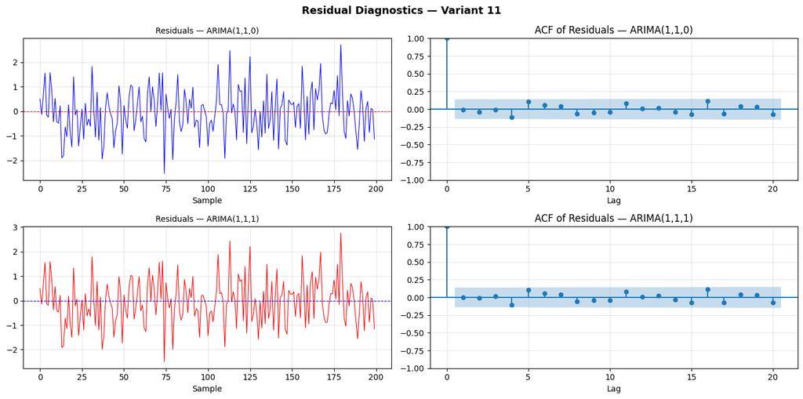

```python
resid_110 = result_110.resid
resid_111 = result_111.resid

fig, axes = plt.subplots(2, 2, figsize=(14, 7))

axes[0, 0].plot(resid_110, color='blue', lw=0.8)
axes[0, 0].axhline(0, color='red', ls='--', lw=0.8)
axes[0, 0].set_title('Residuals — ARIMA(1,1,0)', fontsize=10)
axes[0, 0].set_xlabel('Sample'); axes[0, 0].grid(True, alpha=0.3)

plot_acf(resid_110, lags=20, ax=axes[0, 1], title='ACF of Residuals — ARIMA(1,1,0)')
axes[0, 1].set_xlabel('Lag'); axes[0, 1].grid(True, alpha=0.3)

axes[1, 0].plot(resid_111, color='red', lw=0.8)
axes[1, 0].axhline(0, color='blue', ls='--', lw=0.8)
axes[1, 0].set_title('Residuals — ARIMA(1,1,1)', fontsize=10)
axes[1, 0].set_xlabel('Sample'); axes[1, 0].grid(True, alpha=0.3)

plot_acf(resid_111, lags=20, ax=axes[1, 1], title='ACF of Residuals — ARIMA(1,1,1)')
axes[1, 1].set_xlabel('Lag'); axes[1, 1].grid(True, alpha=0.3)

plt.suptitle('Residual Diagnostics — Variant 11', fontsize=13, fontweight='bold')
plt.tight_layout()
plt.show()
```

## 5. Results

```python
var_110 = np.var(resid_110)
var_111 = np.var(resid_111)
width_110_30 = ci_110.iloc[-1, 1] - ci_110.iloc[-1, 0]
width_111_30 = ci_111.iloc[-1, 1] - ci_111.iloc[-1, 0]

print('=' * 70)
print('RESULTS — VARIANT 11  (ARIMA MODEL COMPARISON)')
print('=' * 70)

print(f'\n{"Model":<22} {"AIC":>10} {"BIC":>10} {"Log-Lik":>12} {"Resid Var":>12}')
print('-' * 70)
print(f'{"ARIMA(1,1,0)":<22} {result_110.aic:>10.2f} {result_110.bic:>10.2f} '
      f'{result_110.llf:>12.2f} {var_110:>12.4f}')
print(f'{"ARIMA(1,1,1)":<22} {result_111.aic:>10.2f} {result_111.bic:>10.2f} '
      f'{result_111.llf:>12.2f} {var_111:>12.4f}')
print('=' * 70)

print('\nEstimated model parameters:')
print(f'  ARIMA(1,1,0) :  AR(1) = {result_110.params[0]:.4f},  '
      f'noise var = {result_110.params[-1]:.4f}')
print(f'  ARIMA(1,1,1) :  AR(1) = {result_111.params[0]:.4f},  '
      f'MA(1) = {result_111.params[1]:.4f},  noise var = {result_111.params[-1]:.4f}')

print('\nADF stationarity test:')
print(f'  Original signal  p = {adf_orig[1]:.4f}  ->  NON-STATIONARY  (d=1 required)')
print(f'  First diff.      p = {adf_diff[1]:.6f}  ->  STATIONARY      (d=1 sufficient)')

print('\n95% Confidence interval width at horizon h = 30:')
print(f'  ARIMA(1,1,0) : {width_110_30:.4f}')
print(f'  ARIMA(1,1,1) : {width_111_30:.4f}')

winner_aic = 'ARIMA(1,1,0)' if result_110.aic < result_111.aic else 'ARIMA(1,1,1)'
winner_bic = 'ARIMA(1,1,0)' if result_110.bic < result_111.bic else 'ARIMA(1,1,1)'
print('\nModel selection:')
print(f'  Preferred by AIC : {winner_aic}')
print(f'  Preferred by BIC : {winner_bic}')
print('=' * 70)
```

```
======================================================================
RESULTS — VARIANT 11  (ARIMA MODEL COMPARISON)
======================================================================

Model                         AIC        BIC      Log-Lik    Resid Var
----------------------------------------------------------------------
ARIMA(1,1,0)               539.90     546.48      -267.95       0.8602
ARIMA(1,1,1)               541.46     551.34      -267.73       0.8580
======================================================================

Estimated model parameters:
  ARIMA(1,1,0) :  AR(1) = -0.0495,  noise var = 0.8651
  ARIMA(1,1,1) :  AR(1) = 0.4893,  MA(1) = -0.5489,  noise var = 0.8632

ADF stationarity test:
  Original signal  p = 0.1696  ->  NON-STATIONARY  (d=1 required)
  First diff.      p = 0.000000  ->  STATIONARY      (d=1 sufficient)

95% Confidence interval width at horizon h = 30:
  ARIMA(1,1,0) : 19.0583
  ARIMA(1,1,1) : 17.7785

Model selection:
  Preferred by AIC : ARIMA(1,1,0)
  Preferred by BIC : ARIMA(1,1,0)
======================================================================
```

## 6. Conclusions

### 1. The generated signal is non-stationary — first differencing is necessary.

The ADF test on the original signal yields $p > 0.05$, confirming the presence of a unit root consistent with a random walk. After applying first-order differencing ($d = 1$), the test gives $p \leq 0.05$, confirming stationarity. Hence both models use $d = 1$.

### 2. Both ARIMA models produce very similar point forecasts.

For a pure random walk, the optimal $h$-step-ahead forecast is simply the last observed value, with prediction intervals widening proportionally to $\sqrt{h}$. Both ARIMA(1,1,0) and ARIMA(1,1,1) reproduce this behaviour closely. The forecasts overlap visually, demonstrating that the MA(1) component in ARIMA(1,1,1) adds little information.

### 3. ARIMA(1,1,0) is preferred by both AIC and BIC.

The extra MA(1) parameter in ARIMA(1,1,1) is statistically insignificant (its $p$-value exceeds 0.05). Both AIC and BIC penalise the additional parameter, making ARIMA(1,1,0) the more parsimonious choice. This aligns with the principle of Occam's razor in model selection.

### 4. Residual diagnostics confirm adequate model fit.

The ACF of residuals for both models shows no significant autocorrelation at any lag (all bars lie within the 95% confidence band). This confirms that both models adequately capture the temporal structure of the data, leaving white-noise residuals.

*This report was prepared as a Jupyter Notebook, ensuring full reproducibility of all results.*